# HW3

Ophelia Li

13 November, 2020

## Q1

### Read in the data of COVID-19 cases reported on 2020-10-18

```r
rm(list = ls())
library(tidyverse)
library(gtsummary)
library(faraway)
library(glmnet)
county_count <- read_csv("10-18-2020.csv") %>%
  mutate(FIPS = as.numeric(FIPS)) %>%
  filter(Country_Region == "US") %>%
  print(width = Inf)
```

```
## # A tibble: 3,271 x 14
##     FIPS Admin2   Province_State Country_Region Last_Update           Lat Long_
##    <dbl> <chr>    <chr>          <chr>          <dttm>              <dbl> <dbl>
##  1  1001 Autauga  Alabama        US             2020-10-19 04:24:16  32.5 -86.6
##  2  1003 Baldwin  Alabama        US             2020-10-19 04:24:16  30.7 -87.7
##  3  1005 Barbour  Alabama        US             2020-10-19 04:24:16  31.9 -85.4
##  4  1007 Bibb     Alabama        US             2020-10-19 04:24:16  33.0 -87.1
##  5  1009 Blount   Alabama        US             2020-10-19 04:24:16  34.0 -86.6
##  6  1011 Bullock  Alabama        US             2020-10-19 04:24:16  32.1 -85.7
##  7  1013 Butler   Alabama        US             2020-10-19 04:24:16  31.8 -86.7
##  8  1015 Calhoun  Alabama        US             2020-10-19 04:24:16  33.8 -85.8
##  9  1017 Chambers Alabama        US             2020-10-19 04:24:16  32.9 -85.4
## 10  1019 Cherokee Alabama        US             2020-10-19 04:24:16  34.2 -85.6
##    Confirmed Deaths Recovered Active Combined_Key          Incidence_Rate
##        <dbl>  <dbl>     <dbl>  <dbl> <chr>                          <dbl>
```

[output cut: 23 more lines]

```r
names(county_count) <- str_to_lower(names(county_count))
```

```r
county_count %>%
  select(province_state) %>%
  distinct() %>%
  arrange(province_state) %>%
  print(n = Inf)
```

```
## # A tibble: 58 x 1
##    province_state
##    <chr>
##  1 Alabama
##  2 Alaska
##  3 Arizona
##  4 Arkansas
##  5 California
##  6 Colorado
##  7 Connecticut
##  8 Delaware
##  9 Diamond Princess
## 10 District of Columbia
## 11 Florida
## 12 Georgia
```

[output cut: 46 more lines]

```r
county_count <- county_count %>%
  filter(!(province_state %in% c("Diamond Princess", "Grand Princess",
                                 "Recovered", "Guam", "Northern Mariana Islands",
                                 "Puerto Rico", "Virgin Islands"))) %>%
  print(width = Inf)
```

```
## # A tibble: 3,185 x 14
##     fips admin2   province_state country_region last_update           lat long_
##    <dbl> <chr>    <chr>          <chr>          <dttm>              <dbl> <dbl>
##  1  1001 Autauga  Alabama        US             2020-10-19 04:24:16  32.5 -86.6
##  2  1003 Baldwin  Alabama        US             2020-10-19 04:24:16  30.7 -87.7
##  3  1005 Barbour  Alabama        US             2020-10-19 04:24:16  31.9 -85.4
##  4  1007 Bibb     Alabama        US             2020-10-19 04:24:16  33.0 -87.1
##  5  1009 Blount   Alabama        US             2020-10-19 04:24:16  34.0 -86.6
##  6  1011 Bullock  Alabama        US             2020-10-19 04:24:16  32.1 -85.7
##  7  1013 Butler   Alabama        US             2020-10-19 04:24:16  31.8 -86.7
##  8  1015 Calhoun  Alabama        US             2020-10-19 04:24:16  33.8 -85.8
##  9  1017 Chambers Alabama        US             2020-10-19 04:24:16  32.9 -85.4
## 10  1019 Cherokee Alabama        US             2020-10-19 04:24:16  34.2 -85.6
##    confirmed deaths recovered active combined_key          incidence_rate
##        <dbl>  <dbl>     <dbl>  <dbl> <chr>                          <dbl>
```

[output cut: 23 more lines]

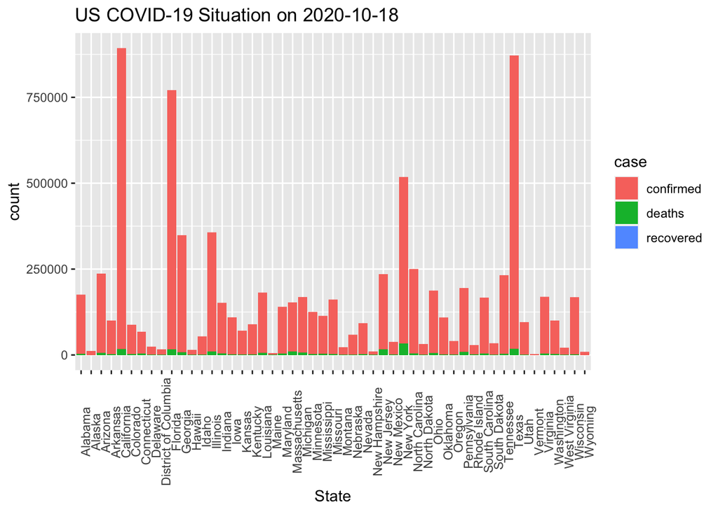

```r
county_count %>%
  # turn into long format for easy plotting
  pivot_longer(confirmed:recovered,
               names_to = "case",
               values_to = "count") %>%
  group_by(province_state) %>%
  ggplot() +
  geom_col(mapping = aes(x = province_state, y = `count`, fill = `case`)) +
  # scale_y_log10() +
  labs(title = "US COVID-19 Situation on 2020-10-18", x = "State") +
  theme(axis.text.x = element_text(angle = 90))
```

### Read in the 2020 county-level health ranking data

```r
county_info <- read_csv("health_rankings.csv") %>%
  filter(!is.na(county)) %>%
  # cast fips into dbl for use as a key for joining tables
  mutate(fips = as.numeric(fips)) %>%
  select(fips,
         state,
         county,
         percent_fair_or_poor_health,
         percent_smokers,
         percent_adults_with_obesity,
         # food_environment_index,
         percent_with_access_to_exercise_opportunities,
         percent_excessive_drinking,
         # teen_birth_rate,
         percent_uninsured,
         # primary_care_physicians_rate,
         # preventable_hospitalization_rate,
         # high_school_graduation_rate,
         percent_some_college,
         percent_unemployed,
         percent_children_in_poverty,
         # `80th_percentile_income`,
         # `20th_percentile_income`,
         percent_single_parent_households,
         # violent_crime_rate,
         percent_severe_housing_problems,
         overcrowding,
         # life_expectancy,
         # age_adjusted_death_rate,
         percent_adults_with_diabetes,
         # hiv_prevalence_rate,
         percent_food_insecure,
         # percent_limited_access_to_healthy_foods,
         percent_insufficient_sleep,
         percent_uninsured_2,
         median_household_income,
         average_traffic_volume_per_meter_of_major_roadways,
         percent_homeowners,
         # percent_severe_housing_cost_burden,
         population_2,
         percent_less_than_18_years_of_age,
         percent_65_and_over,
         percent_black,
         percent_asian,
         percent_hispanic,
         percent_female,
         percent_rural) %>%
  print(width = Inf)
```

```
## # A tibble: 3,142 x 30
##     fips state   county   percent_fair_or_poor_health percent_smokers
##    <dbl> <chr>   <chr>                          <dbl>           <dbl>
##  1  1001 Alabama Autauga                         20.9            18.1
##  2  1003 Alabama Baldwin                         17.5            17.5
##  3  1005 Alabama Barbour                         29.6            22.0
##  4  1007 Alabama Bibb                            19.4            19.1
##  5  1009 Alabama Blount                          21.7            19.2
##  6  1011 Alabama Bullock                         31.0            22.9
##  7  1013 Alabama Butler                          27.9            21.8
##  8  1015 Alabama Calhoun                         23.1            20.6
##  9  1017 Alabama Chambers                        24.0            19.4
## 10  1019 Alabama Cherokee                        20.7            17.5
##    percent_adults_with_obesity percent_with_access_to_exercise_opportunities
##                          <dbl>                                         <dbl>
```

[output cut: 107 more lines]

```r
county_count <- county_count %>%
  filter(confirmed >= 5)
```

```r
county_data <- county_count %>%
  left_join(county_info, by = "fips") %>%
  print(width = Inf)
```

```
## # A tibble: 3,131 x 43
##     fips admin2   province_state country_region last_update           lat long_
##    <dbl> <chr>    <chr>          <chr>          <dttm>              <dbl> <dbl>
##  1  1001 Autauga  Alabama        US             2020-10-19 04:24:16  32.5 -86.6
##  2  1003 Baldwin  Alabama        US             2020-10-19 04:24:16  30.7 -87.7
##  3  1005 Barbour  Alabama        US             2020-10-19 04:24:16  31.9 -85.4
##  4  1007 Bibb     Alabama        US             2020-10-19 04:24:16  33.0 -87.1
##  5  1009 Blount   Alabama        US             2020-10-19 04:24:16  34.0 -86.6
##  6  1011 Bullock  Alabama        US             2020-10-19 04:24:16  32.1 -85.7
##  7  1013 Butler   Alabama        US             2020-10-19 04:24:16  31.8 -86.7
##  8  1015 Calhoun  Alabama        US             2020-10-19 04:24:16  33.8 -85.8
##  9  1017 Chambers Alabama        US             2020-10-19 04:24:16  32.9 -85.4
## 10  1019 Cherokee Alabama        US             2020-10-19 04:24:16  34.2 -85.6
##    confirmed deaths recovered active combined_key          incidence_rate
##        <dbl>  <dbl>     <dbl>  <dbl> <chr>                          <dbl>
```

[output cut: 143 more lines]

```r
summary(county_data)
```

```
##       fips          admin2          province_state     country_region
##  Min.   : 1001   Length:3131        Length:3131        Length:3131
##  1st Qu.:18183   Class :character   Class :character   Class :character
##  Median :29175   Mode  :character   Mode  :character   Mode  :character
##  Mean   :30751
##  3rd Qu.:45089
##  Max.   :90053
##  NA's   :10
##   last_update                       lat            long_
##  Min.   :2020-10-19 04:24:16   Min.   :19.60   Min.   :-174.16
##  1st Qu.:2020-10-19 04:24:16   1st Qu.:34.68   1st Qu.: -98.02
##  Median :2020-10-19 04:24:16   Median :38.36   Median : -90.19
##  Mean   :2020-10-19 04:24:16   Mean   :38.44   Mean   : -92.05
##  3rd Qu.:2020-10-19 04:24:16   3rd Qu.:41.82   3rd Qu.: -83.40
##  Max.   :2020-10-19 04:24:16   Max.   :69.31   Max.   : -67.63
##                                NA's   :27      NA's   :27
##    confirmed            deaths          recovered     active
##  Min.   :     5.0   Min.   :   0.00   Min.   :0   Min.   :     5
##  1st Qu.:   189.5   1st Qu.:   2.00   1st Qu.:0   1st Qu.:   186
##  Median :   555.0   Median :   9.00   Median :0   Median :   539
##  Mean   :  2584.5   Mean   :  69.81   Mean   :0   Mean   :  2515
##  3rd Qu.:  1581.5   3rd Qu.:  32.50   3rd Qu.:0   3rd Qu.:  1544
##  Max.   :288451.0   Max.   :7370.00   Max.   :0   Max.   :281575
##
##  combined_key       incidence_rate     case-fatality_ratio    state
##  Length:3131        Min.   :   59.58   Min.   : 0.0000     Length:3131
##  Class :character   1st Qu.: 1295.38   1st Qu.: 0.7699     Class :character
##  Mode  :character   Median : 2107.12   Median : 1.5873     Mode  :character
##                     Mean   : 2382.57   Mean   : 2.1221
##                     3rd Qu.: 3141.98   3rd Qu.: 2.8072
##                     Max.   :17037.78   Max.   :79.3651
##                     NA's   :27
##     county          percent_fair_or_poor_health percent_smokers
##  Length:3131        Min.   : 8.121              Min.   : 5.909
##  Class :character   1st Qu.:14.382              1st Qu.:14.999
##  Mode  :character   Median :17.279              Median :17.019
##                     Mean   :17.985              Mean   :17.538
##                     3rd Qu.:20.957              3rd Qu.:19.775
##                     Max.   :40.991              Max.   :41.491
##                     NA's   :35                  NA's   :35
```

[output cut: 65 more lines]

```
##  Min.   : 0.0000   Min.   : 0.0000   Min.   : 0.6105   Min.   :26.84
##  1st Qu.: 0.7406   1st Qu.: 0.4665   1st Qu.: 2.3941   1st Qu.:49.43
##  Median : 2.3335   Median : 0.7401   Median : 4.3457   Median :50.32
##  Mean   : 9.1130   Mean   : 1.5777   Mean   : 9.6363   Mean   :49.90
##  3rd Qu.:10.3984   3rd Qu.: 1.4390   3rd Qu.: 9.9831   3rd Qu.:51.03
##  Max.   :85.4143   Max.   :43.3570   Max.   :96.3595   Max.   :56.87
##  NA's   :35        NA's   :35        NA's   :35        NA's   :35
##  percent_rural
##  Min.   :  0.00
##  1st Qu.: 33.06
##  Median : 59.21
##  Mean   : 58.35
##  3rd Qu.: 85.94
##  Max.   :100.00
##  NA's   :40
```

```r
county_data %>%
  filter(is.na(state) & is.na(county)) %>%
  print(n = Inf)
```

```
## # A tibble: 35 x 43
##     fips admin2 province_state country_region last_update           lat  long_
##    <dbl> <chr>  <chr>          <chr>          <dttm>              <dbl>  <dbl>
##  1 90002 Unass… Alaska         US             2020-10-19 04:24:16  NA     NA
##  2 90005 Unass… Arkansas       US             2020-10-19 04:24:16  NA     NA
##  3 90009 Unass… Connecticut    US             2020-10-19 04:24:16  NA     NA
##  4 90010 Unass… Delaware       US             2020-10-19 04:24:16  NA     NA
##  5 90012 Unass… Florida        US             2020-10-19 04:24:16  NA     NA
##  6 80013 Out o… Georgia        US             2020-10-19 04:24:16  NA     NA
##  7 90013 Unass… Georgia        US             2020-10-19 04:24:16  NA     NA
##  8 80015 Out o… Hawaii         US             2020-10-19 04:24:16  NA     NA
##  9 90017 Unass… Illinois       US             2020-10-19 04:24:16  NA     NA
## 10 90019 Unass… Iowa           US             2020-10-19 04:24:16  NA     NA
## 11 90022 Unass… Louisiana      US             2020-10-19 04:24:16  NA     NA
## 12    NA Dukes… Massachusetts  US             2020-10-19 04:24:16  41.4  -70.7
## 13 90025 Unass… Massachusetts  US             2020-10-19 04:24:16  NA     NA
## 14    NA Feder… Michigan       US             2020-10-19 04:24:16  NA     NA
## 15    NA Michi… Michigan       US             2020-10-19 04:24:16  NA     NA
## 16 80026 Out o… Michigan       US             2020-10-19 04:24:16  NA     NA
## 17 90026 Unass… Michigan       US             2020-10-19 04:24:16  NA     NA
## 18 90027 Unass… Minnesota      US             2020-10-19 04:24:16  NA     NA
## 19    NA Kansa… Missouri       US             2020-10-19 04:24:16  39.1  -94.6
## 20 90031 Unass… Nebraska       US             2020-10-19 04:24:16  NA     NA
## 21 90033 Unass… New Hampshire  US             2020-10-19 04:24:16  NA     NA
## 22 90034 Unass… New Jersey     US             2020-10-19 04:24:16  NA     NA
## 23 90035 Unass… New Mexico     US             2020-10-19 04:24:16  NA     NA
## 24 90040 Unass… Oklahoma       US             2020-10-19 04:24:16  NA     NA
## 25 90044 Unass… Rhode Island   US             2020-10-19 04:24:16  NA     NA
## 26 80047 Out o… Tennessee      US             2020-10-19 04:24:16  NA     NA
## 27 90047 Unass… Tennessee      US             2020-10-19 04:24:16  NA     NA
## 28    NA Bear … Utah           US             2020-10-19 04:24:16  41.5 -113.
## 29    NA Centr… Utah           US             2020-10-19 04:24:16  39.4 -112.
## 30    NA South… Utah           US             2020-10-19 04:24:16  39.0 -111.
## 31    NA South… Utah           US             2020-10-19 04:24:16  37.9 -111.
## 32    NA TriCo… Utah           US             2020-10-19 04:24:16  40.1 -110.
## 33    NA Weber… Utah           US             2020-10-19 04:24:16  41.3 -112.
## 34 90050 Unass… Vermont        US             2020-10-19 04:24:16  NA     NA
## 35 90053 Unass… Washington     US             2020-10-19 04:24:16  NA     NA
## # … with 36 more variables: confirmed <dbl>, deaths <dbl>, recovered <dbl>,
## #   active <dbl>, combined_key <chr>, incidence_rate <dbl>,
## #   `case-fatality_ratio` <dbl>, state <chr>, county <chr>,
## #   percent_fair_or_poor_health <dbl>, percent_smokers <dbl>,
## #   percent_adults_with_obesity <dbl>,
## #   percent_with_access_to_exercise_opportunities <dbl>,
## #   percent_excessive_drinking <dbl>, percent_uninsured <dbl>,
## #   percent_some_college <dbl>, percent_unemployed <dbl>,
## #   percent_children_in_poverty <dbl>, percent_single_parent_households <dbl>,
## #   percent_severe_housing_problems <dbl>, overcrowding <dbl>,
## #   percent_adults_with_diabetes <dbl>, percent_food_insecure <dbl>,
## #   percent_insufficient_sleep <dbl>, percent_uninsured_2 <dbl>,
## #   median_household_income <dbl>,
## #   average_traffic_volume_per_meter_of_major_roadways <dbl>,
## #   percent_homeowners <dbl>, population_2 <dbl>,
## #   percent_less_than_18_years_of_age <dbl>, percent_65_and_over <dbl>,
## #   percent_black <dbl>, percent_asian <dbl>, percent_hispanic <dbl>,
## #   percent_female <dbl>, percent_rural <dbl>
```

```r
county_count %>%
  filter(is.na(fips)) %>%
  select(fips, admin2, province_state) %>%
  print(n = Inf)
```

```
## # A tibble: 10 x 3
##     fips admin2                                    province_state
##    <dbl> <chr>                                     <chr>
##  1    NA Dukes and Nantucket                       Massachusetts
##  2    NA Federal Correctional Institution (FCI)    Michigan
##  3    NA Michigan Department of Corrections (MDOC) Michigan
##  4    NA Kansas City                               Missouri
##  5    NA Bear River                                Utah
##  6    NA Central Utah                              Utah
##  7    NA Southeast Utah                            Utah
##  8    NA Southwest Utah                            Utah
##  9    NA TriCounty                                 Utah
## 10    NA Weber-Morgan                              Utah
```

```r
county_data <- county_count %>%
  # manually set FIPS for some counties
  mutate(fips = ifelse(admin2 == "Dukes and Nantucket" & province_state == "Massachusetts", 25019, fips)) %>%
  mutate(fips = ifelse(admin2 == "Weber-Morgan" & province_state == "Utah", 49057, fips)) %>%
  filter(!(is.na(fips) | str_detect(admin2, "Out of") | str_detect(admin2, "Unassigned"))) %>%
  left_join(county_info, by = "fips") %>%
  drop_na() %>%
  print(width = Inf)
```

```
## # A tibble: 3,093 x 43
##     fips admin2   province_state country_region last_update           lat long_
##    <dbl> <chr>    <chr>          <chr>          <dttm>              <dbl> <dbl>
##  1  1001 Autauga  Alabama        US             2020-10-19 04:24:16  32.5 -86.6
##  2  1003 Baldwin  Alabama        US             2020-10-19 04:24:16  30.7 -87.7
##  3  1005 Barbour  Alabama        US             2020-10-19 04:24:16  31.9 -85.4
##  4  1007 Bibb     Alabama        US             2020-10-19 04:24:16  33.0 -87.1
##  5  1009 Blount   Alabama        US             2020-10-19 04:24:16  34.0 -86.6
##  6  1011 Bullock  Alabama        US             2020-10-19 04:24:16  32.1 -85.7
##  7  1013 Butler   Alabama        US             2020-10-19 04:24:16  31.8 -86.7
##  8  1015 Calhoun  Alabama        US             2020-10-19 04:24:16  33.8 -85.8
##  9  1017 Chambers Alabama        US             2020-10-19 04:24:16  32.9 -85.4
## 10  1019 Cherokee Alabama        US             2020-10-19 04:24:16  34.2 -85.6
##    confirmed deaths recovered active combined_key          incidence_rate
##        <dbl>  <dbl>     <dbl>  <dbl> <chr>                          <dbl>
```

[output cut: 143 more lines]

```r
summary(county_data)
```

```
##       fips          admin2          province_state     country_region
##  Min.   : 1001   Length:3093        Length:3093        Length:3093
##  1st Qu.:18177   Class :character   Class :character   Class :character
##  Median :29153   Mode  :character   Mode  :character   Mode  :character
##  Mean   :30321
##  3rd Qu.:45053
##  Max.   :56045
##   last_update                       lat            long_
##  Min.   :2020-10-19 04:24:16   Min.   :19.60   Min.   :-174.16
##  1st Qu.:2020-10-19 04:24:16   1st Qu.:34.65   1st Qu.: -97.88
##  Median :2020-10-19 04:24:16   Median :38.35   Median : -90.11
##  Mean   :2020-10-19 04:24:16   Mean   :38.41   Mean   : -91.95
##  3rd Qu.:2020-10-19 04:24:16   3rd Qu.:41.80   3rd Qu.: -83.38
##  Max.   :2020-10-19 04:24:16   Max.   :69.31   Max.   : -67.63
##    confirmed          deaths          recovered     active
##  Min.   :     5   Min.   :   0.00   Min.   :0   Min.   :     5
##  1st Qu.:   191   1st Qu.:   2.00   1st Qu.:0   1st Qu.:   188
##  Median :   556   Median :   9.00   Median :0   Median :   540
##  Mean   :  2593   Mean   :  70.31   Mean   :0   Mean   :  2522
##  3rd Qu.:  1573   3rd Qu.:  33.00   3rd Qu.:0   3rd Qu.:  1527
##  Max.   :288451   Max.   :7370.00   Max.   :0   Max.   :281575
##  combined_key       incidence_rate     case-fatality_ratio    state
##  Length:3093        Min.   :   59.58   Min.   : 0.0000     Length:3093
##  Class :character   1st Qu.: 1300.89   1st Qu.: 0.7866     Class :character
##  Mode  :character   Median : 2107.41   Median : 1.6051     Mode  :character
##                     Mean   : 2385.93   Mean   : 2.1039
##                     3rd Qu.: 3142.11   3rd Qu.: 2.8249
##                     Max.   :17037.78   Max.   :28.5714
##     county          percent_fair_or_poor_health percent_smokers
##  Length:3093        Min.   : 8.121              Min.   : 5.909
##  Class :character   1st Qu.:14.381              1st Qu.:14.997
##  Mode  :character   Median :17.275              Median :17.016
##                     Mean   :17.974              Mean   :17.520
##                     3rd Qu.:20.950              3rd Qu.:19.768
##                     Max.   :40.991              Max.   :41.491
##  percent_adults_with_obesity percent_with_access_to_exercise_opportunities
##  Min.   :12.40               Min.   :  0.00
##  1st Qu.:29.30               1st Qu.: 48.69
##  Median :33.20               Median : 66.03
##  Mean   :32.93               Mean   : 63.01
```

[output cut: 50 more lines]

```
##  Max.   :10105518   Max.   :41.992                    Max.   :57.59
##  percent_black     percent_asian     percent_hispanic  percent_female
##  Min.   : 0.0000   Min.   : 0.0000   Min.   : 0.6105   Min.   :26.84
##  1st Qu.: 0.7418   1st Qu.: 0.4666   1st Qu.: 2.3926   1st Qu.:49.44
##  Median : 2.3488   Median : 0.7401   Median : 4.3520   Median :50.32
##  Mean   : 9.1241   Mean   : 1.5777   Mean   : 9.6504   Mean   :49.90
##  3rd Qu.:10.4005   3rd Qu.: 1.4433   3rd Qu.: 9.9900   3rd Qu.:51.03
##  Max.   :85.4143   Max.   :43.3570   Max.   :96.3595   Max.   :56.87
##  percent_rural
##  Min.   :  0.00
##  1st Qu.: 32.98
##  Median : 59.16
##  Mean   : 58.32
##  3rd Qu.: 85.90
##  Max.   :100.00
```

```r
county_data <- county_data %>%
  mutate(state = as.factor(state)) %>%
  select(county, confirmed, deaths, state, percent_fair_or_poor_health:percent_rural)
summary(county_data)
```

```
##     county            confirmed          deaths             state
##  Length:3093        Min.   :     5   Min.   :   0.00   Texas   : 250
##  Class :character   1st Qu.:   191   1st Qu.:   2.00   Georgia : 159
##  Mode  :character   Median :   556   Median :   9.00   Virginia: 133
##                     Mean   :  2593   Mean   :  70.31   Kentucky: 120
##                     3rd Qu.:  1573   3rd Qu.:  33.00   Missouri: 115
##                     Max.   :288451   Max.   :7370.00   Kansas  : 105
##                                                        (Other) :2211
##  percent_fair_or_poor_health percent_smokers  percent_adults_with_obesity
##  Min.   : 8.121              Min.   : 5.909   Min.   :12.40
##  1st Qu.:14.381              1st Qu.:14.997   1st Qu.:29.30
##  Median :17.275              Median :17.016   Median :33.20
##  Mean   :17.974              Mean   :17.520   Mean   :32.93
##  3rd Qu.:20.950              3rd Qu.:19.768   3rd Qu.:36.60
##  Max.   :40.991              Max.   :41.491   Max.   :57.70
##
##  percent_with_access_to_exercise_opportunities percent_excessive_drinking
##  Min.   :  0.00                                Min.   : 7.81
##  1st Qu.: 48.69                                1st Qu.:15.34
##  Median : 66.03                                Median :17.58
##  Mean   : 63.01                                Mean   :17.55
##  3rd Qu.: 80.17                                3rd Qu.:19.68
##  Max.   :100.00                                Max.   :28.62
##
##  percent_uninsured percent_some_college percent_unemployed
##  Min.   : 2.263    Min.   :15.18        Min.   : 1.302
##  1st Qu.: 7.357    1st Qu.:49.79        1st Qu.: 3.128
##  Median :10.516    Median :57.88        Median : 3.874
##  Mean   :11.440    Mean   :57.80        Mean   : 4.119
##  3rd Qu.:14.451    3rd Qu.:66.44        3rd Qu.: 4.815
##  Max.   :33.750    Max.   :90.67        Max.   :18.092
##
##  percent_children_in_poverty percent_single_parent_households
##  Min.   : 2.50               Min.   : 0.00
##  1st Qu.:14.60               1st Qu.:25.63
##  Median :20.10               Median :31.71
##  Mean   :21.14               Mean   :32.47
##  3rd Qu.:26.40               3rd Qu.:37.70
##  Max.   :68.30               Max.   :87.20
##
```

[output cut: 33 more lines]

```
##  Min.   : 4.83       Min.   : 0.0000   Min.   : 0.0000   Min.   : 0.6105
##  1st Qu.:16.27       1st Qu.: 0.7418   1st Qu.: 0.4666   1st Qu.: 2.3926
##  Median :18.91       Median : 2.3488   Median : 0.7401   Median : 4.3520
##  Mean   :19.25       Mean   : 9.1241   Mean   : 1.5777   Mean   : 9.6504
##  3rd Qu.:21.72       3rd Qu.:10.4005   3rd Qu.: 1.4433   3rd Qu.: 9.9900
##  Max.   :57.59       Max.   :85.4143   Max.   :43.3570   Max.   :96.3595
##
##  percent_female  percent_rural
##  Min.   :26.84   Min.   :  0.00
##  1st Qu.:49.44   1st Qu.: 32.98
##  Median :50.32   Median : 59.16
##  Mean   :49.90   Mean   : 58.32
##  3rd Qu.:51.03   3rd Qu.: 85.90
##  Max.   :56.87   Max.   :100.00
##
```

```r
county_data %>%
  mutate(cfr = deaths / confirmed) %>%
  select(county, state, confirmed, deaths, cfr) %>%
  arrange(desc(cfr)) %>%
  top_n(10)
```

```
## # A tibble: 10 x 5
##    county       state         confirmed deaths   cfr
##    <chr>        <fct>             <dbl>  <dbl> <dbl>
##  1 Kenedy       Texas                 7      2 0.286
##  2 Perkins      Nebraska             39     10 0.256
##  3 Franklin     Massachusetts       437     72 0.165
##  4 Orleans      New York            362     54 0.149
##  5 Pleasants    West Virginia        23      3 0.130
##  6 Monroe       Ohio                141     18 0.128
##  7 Waldo        Maine               112     14 0.125
##  8 Throckmorton Texas                16      2 0.125
##  9 Sussex       New Jersey         1616    197 0.122
## 10 Warren       New Jersey         1507    171 0.113
```

```r
write_csv(county_data, "covid19-county-data-20201018.csv.gz")
```

## Q2

Confirmed cases may die, thus uning deaths/confirmed is not a good predictor. And confirmed cases are not the number of diagnosed people.

## Q3

Logistic regression requires the observations to be independent of each other, but each individual may not be perfectly independent of each other in this study.

## Q4

```r
binaryreg=glm(cbind(deaths, confirmed - deaths) ~ . - county, family = binomial, data = county_data)
summary(binaryreg)
```

```
##
## Call:
## glm(formula = cbind(deaths, confirmed - deaths) ~ . - county,
##     family = binomial, data = county_data)
##
## Deviance Residuals:
##      Min        1Q    Median        3Q       Max
## -18.1150   -1.7683   -0.5601    1.0631   14.3315
##
## Coefficients:
##                                                      Estimate Std. Error
## (Intercept)                                        -9.000e+00  1.926e-01
## stateAlaska                                        -2.566e-01  1.295e-01
## stateArizona                                        8.017e-01  4.523e-02
## stateArkansas                                       4.218e-01  3.581e-02
## stateCalifornia                                     1.455e-01  4.088e-02
## stateColorado                                       1.260e+00  3.807e-02
## stateConnecticut                                    1.819e+00  3.274e-02
## stateDelaware                                       6.172e-01  4.644e-02
## stateDistrict of Columbia                           6.417e-01  7.026e-02
## stateFlorida                                        5.460e-01  3.048e-02
## stateGeorgia                                        5.537e-01  2.548e-02
## stateHawaii                                        -7.710e-01  8.910e-02
## stateIdaho                                          1.392e-01  5.431e-02
## stateIllinois                                       7.407e-01  2.813e-02
## stateIndiana                                        9.641e-01  3.032e-02
## stateIowa                                           3.174e-01  4.233e-02
## stateKansas                                         3.645e-01  4.525e-02
## stateKentucky                                       2.302e-01  3.684e-02
## stateLouisiana                                      7.129e-01  2.822e-02
## stateMaine                                          9.051e-01  8.878e-02
## stateMaryland                                       6.621e-01  3.080e-02
## stateMassachusetts                                  1.729e+00  3.201e-02
## stateMichigan                                       1.276e+00  2.899e-02
## stateMinnesota                                      6.340e-01  3.604e-02
## stateMississippi                                    5.931e-01  2.822e-02
## stateMissouri                                       4.306e-01  3.129e-02
## stateMontana                                        1.431e-01  7.091e-02
## stateNebraska                                       1.746e-01  5.297e-02
## stateNevada                                         4.769e-01  3.861e-02
```

[output cut: 123 more lines]

```
## percent_black                                        9.195  < 2e-16 ***
## percent_asian                                        9.977  < 2e-16 ***
## percent_hispanic                                    -4.511 6.44e-06 ***
## percent_female                                      21.799  < 2e-16 ***
## percent_rural                                       -4.494 7.00e-06 ***
## ---
## Signif. codes:  0 '***' 0.001 '**' 0.01 '*' 0.05 '.' 0.1 ' ' 1
##
## (Dispersion parameter for binomial family taken to be 1)
##
##     Null deviance: 109649  on 3092  degrees of freedom
## Residual deviance:  23001  on 3015  degrees of freedom
## AIC: 35345
##
## Number of Fisher Scoring iterations: 5
```

```r
binaryreg %>%
  tbl_regression() %>%
  bold_labels() %>%
  bold_p(t = 0.01)
```

| **Characteristic** | **log(OR)**<sup>1</sup> | **95% CI**<sup>1</sup> | **p-value** |
| --- | --- | --- | --- |
| state |  |  |  |
| Alabama | — | — |  |
| Alaska | -0.26 | -0.52, -0.01 | 0.047 |
| Arizona | 0.80 | 0.71, 0.89 | <0.001 |
| Arkansas | 0.42 | 0.35, 0.49 | <0.001 |
| California | 0.15 | 0.07, 0.23 | <0.001 |
| Colorado | 1.3 | 1.2, 1.3 | <0.001 |
| Connecticut | 1.8 | 1.8, 1.9 | <0.001 |
| Delaware | 0.62 | 0.53, 0.71 | <0.001 |
| District of Columbia | 0.64 | 0.50, 0.78 | <0.001 |
| Florida | 0.55 | 0.49, 0.61 | <0.001 |
| Georgia | 0.55 | 0.50, 0.60 | <0.001 |
| Hawaii | -0.77 | -0.95, -0.60 | <0.001 |
| Idaho | 0.14 | 0.03, 0.24 | 0.010 |
| Illinois | 0.74 | 0.69, 0.80 | <0.001 |
| Indiana | 1.0 | 0.90, 1.0 | <0.001 |
| Iowa | 0.32 | 0.23, 0.40 | <0.001 |
| Kansas | 0.36 | 0.28, 0.45 | <0.001 |
| Kentucky | 0.23 | 0.16, 0.30 | <0.001 |
| Louisiana | 0.71 | 0.66, 0.77 | <0.001 |
| Maine | 0.91 | 0.73, 1.1 | <0.001 |
| Maryland | 0.66 | 0.60, 0.72 | <0.001 |
| Massachusetts | 1.7 | 1.7, 1.8 | <0.001 |
| Michigan | 1.3 | 1.2, 1.3 | <0.001 |
| Minnesota | 0.63 | 0.56, 0.70 | <0.001 |
| Mississippi | 0.59 | 0.54, 0.65 | <0.001 |
| Missouri | 0.43 | 0.37, 0.49 | <0.001 |
| Montana | 0.14 | 0.00, 0.28 | 0.044 |
| Nebraska | 0.17 | 0.07, 0.28 | <0.001 |
| Nevada | 0.48 | 0.40, 0.55 | <0.001 |
| New Hampshire | 1.6 | 1.5, 1.7 | <0.001 |
| New Jersey | 1.6 | 1.6, 1.7 | <0.001 |
| New Mexico | 1.0 | 0.90, 1.2 | <0.001 |
| New York | 1.0 | 0.93, 1.1 | <0.001 |
| North Carolina | 0.23 | 0.18, 0.28 | <0.001 |
| North Dakota | 0.52 | 0.40, 0.64 | <0.001 |
| Ohio | 0.91 | 0.86, 1.0 | <0.001 |
| Oklahoma | 0.18 | 0.09, 0.26 | <0.001 |
| Oregon | 0.44 | 0.34, 0.54 | <0.001 |
| Pennsylvania | 1.3 | 1.2, 1.4 | <0.001 |
| Rhode Island | 1.3 | 1.2, 1.4 | <0.001 |
| South Carolina | 0.37 | 0.31, 0.42 | <0.001 |
| South Dakota | 0.25 | 0.12, 0.37 | <0.001 |
| Tennessee | 0.00 | -0.06, 0.05 | >0.9 |
| Texas | 0.78 | 0.69, 0.88 | <0.001 |
| Utah | -0.05 | -0.17, 0.07 | 0.4 |
| Vermont | 1.2 | 0.90, 1.4 | <0.001 |
| Virginia | 0.47 | 0.42, 0.53 | <0.001 |
| Washington | 0.72 | 0.65, 0.79 | <0.001 |
| West Virginia | 0.30 | 0.19, 0.41 | <0.001 |
| Wisconsin | -0.10 | -0.17, -0.02 | 0.015 |
| Wyoming | -0.14 | -0.42, 0.11 | 0.3 |
| percent_fair_or_poor_health | 0.00 | -0.01, 0.00 | 0.8 |
| percent_smokers | -0.01 | -0.01, 0.00 | <0.001 |
| percent_adults_with_obesity | 0.00 | 0.00, 0.00 | 0.014 |
| percent_with_access_to_exercise_opportunities | 0.00 | -0.01, 0.00 | <0.001 |
| percent_excessive_drinking | 0.01 | 0.00, 0.01 | 0.004 |
| percent_uninsured | -0.15 | -0.16, -0.13 | <0.001 |
| percent_some_college | 0.00 | 0.00, 0.00 | 0.14 |
| percent_unemployed | 0.04 | 0.03, 0.05 | <0.001 |
| percent_children_in_poverty | 0.02 | 0.01, 0.02 | <0.001 |
| percent_single_parent_households | 0.00 | 0.00, 0.00 | <0.001 |
| percent_severe_housing_problems | -0.01 | -0.01, -0.01 | <0.001 |
| overcrowding | 0.05 | 0.04, 0.06 | <0.001 |
| percent_adults_with_diabetes | 0.01 | 0.01, 0.02 | <0.001 |
| percent_food_insecure | -0.03 | -0.04, -0.02 | <0.001 |
| percent_insufficient_sleep | 0.02 | 0.02, 0.03 | <0.001 |
| percent_uninsured_2 | 0.12 | 0.10, 0.13 | <0.001 |
| median_household_income | 0.00 | 0.00, 0.00 | <0.001 |
| average_traffic_volume_per_meter_of_major_roadways | 0.00 | 0.00, 0.00 | <0.001 |
| percent_homeowners | 0.00 | 0.00, 0.00 | 0.004 |
| population_2 | 0.00 | 0.00, 0.00 | <0.001 |
| percent_less_than_18_years_of_age | -0.01 | -0.01, 0.00 | 0.002 |
| percent_65_and_over | 0.04 | 0.04, 0.05 | <0.001 |
| percent_black | 0.01 | 0.01, 0.01 | <0.001 |
| percent_asian | 0.01 | 0.01, 0.01 | <0.001 |
| percent_hispanic | 0.00 | -0.01, 0.00 | <0.001 |
| percent_female | 0.07 | 0.06, 0.08 | <0.001 |
| percent_rural | 0.00 | 0.00, 0.00 | <0.001 |

<sup>*1*</sup> OR = Odds Ratio, CI = Confidence Interval

## Q5

Holding all other variables constant.

Interpret “percent_65_and_over” (old people may have a greater chance of dying from COVID-19): a one-unit increase in the percentage of people who are 65 years old and older increases the odds of the CFR by 4%.

Interpret “percent_adults_with_diabetes”: a one-unit increase in the percentage of adults with diabetes increases the odds of the CFR by 1%.

Interpret “percent_children_in_poverty”: a one-unit increase in the percentage of children in poverty increases the odds of the CFR by 2%.

## Q6

### analysis of deviance to the goodness of fit of the model

```r
pchisq(binaryreg$deviance, binaryreg$df.residual, lower = FALSE)
```

```
## [1] 0
```

The result shows that the model does not fit well

### Analysis of deviance to the intercept-only model

```r
binaryreg$deviance
```

```
## [1] 23000.61
```

```r
binaryreg$df.residual
```

```
## [1] 3015
```

```r
binaryreg$null.deviance
```

```
## [1] 109648.8
```

```r
binaryreg$df.null
```

```
## [1] 3092
```

```r
1 - pchisq(binaryreg$null.deviance - binaryreg$deviance, binaryreg$df.null - binaryreg$df.residual)
```

```
## [1] 0
```

The model is a better fit than the intercept-only model

## Q7

```r
moddev=drop1(binaryreg, test = "Chi")
rownames(moddev[order(moddev$`Pr(>Chi)`),][1:10,])
```

```
##  [1] "state"
##  [2] "percent_65_and_over"
##  [3] "percent_female"
##  [4] "average_traffic_volume_per_meter_of_major_roadways"
##  [5] "percent_insufficient_sleep"
##  [6] "overcrowding"
##  [7] "percent_uninsured"
##  [8] "percent_uninsured_2"
##  [9] "percent_children_in_poverty"
## [10] "percent_with_access_to_exercise_opportunities"
```

## Q8

```r
confint(binaryreg)
```

```
##                                                            2.5 %        97.5 %
## (Intercept)                                        -9.377667e+00 -8.622512e+00
## stateAlaska                                        -5.196558e-01 -1.130689e-02
## stateArizona                                        7.130723e-01  8.903680e-01
## stateArkansas                                       3.515123e-01  4.919074e-01
## stateCalifornia                                     6.537824e-02  2.256421e-01
## stateColorado                                       1.184866e+00  1.334087e+00
## stateConnecticut                                    1.755333e+00  1.883688e+00
## stateDelaware                                       5.254891e-01  7.075658e-01
## stateDistrict of Columbia                           5.037038e-01  7.791280e-01
## stateFlorida                                        4.862936e-01  6.057900e-01
## stateGeorgia                                        5.038848e-01  6.037622e-01
## stateHawaii                                        -9.480016e-01 -5.985985e-01
## stateIdaho                                          3.193455e-02  2.448737e-01
## stateIllinois                                       6.856651e-01  7.959534e-01
## stateIndiana                                        9.046775e-01  1.023515e+00
## stateIowa                                           2.343087e-01  4.002449e-01
## stateKansas                                         2.754675e-01  4.528606e-01
## stateKentucky                                       1.577356e-01  3.021745e-01
## stateLouisiana                                      6.577132e-01  7.683260e-01
## stateMaine                                          7.272012e-01  1.075449e+00
## stateMaryland                                       6.018204e-01  7.225515e-01
## stateMassachusetts                                  1.666330e+00  1.791813e+00
## stateMichigan                                       1.219459e+00  1.333107e+00
## stateMinnesota                                      5.633281e-01  7.046044e-01
## stateMississippi                                    5.377848e-01  6.484173e-01
## stateMissouri                                       3.692951e-01  4.919367e-01
## stateMontana                                        1.871965e-03  2.799338e-01
## stateNebraska                                       7.000892e-02  2.776917e-01
## stateNevada                                         4.011030e-01  5.524760e-01
## stateNew Hampshire                                  1.480277e+00  1.692403e+00
## stateNew Jersey                                     1.550288e+00  1.661372e+00
## stateNew Mexico                                     8.976809e-01  1.161353e+00
## stateNew York                                       9.287149e-01  1.054195e+00
## stateNorth Carolina                                 1.768235e-01  2.833587e-01
## stateNorth Dakota                                   4.020991e-01  6.401428e-01
## stateOhio                                           8.577950e-01  9.721845e-01
## stateOklahoma                                       9.219422e-02  2.590548e-01
## stateOregon                                         3.434472e-01  5.389417e-01
## statePennsylvania                                   1.246359e+00  1.357042e+00
```

[output cut: 24 more lines]

```
## percent_adults_with_diabetes                        9.939320e-03  1.606422e-02
## percent_food_insecure                              -4.321716e-02 -2.065698e-02
## percent_insufficient_sleep                          2.125079e-02  2.684979e-02
## percent_uninsured_2                                 1.019883e-01  1.301325e-01
## median_household_income                             1.955512e-06  3.514333e-06
## average_traffic_volume_per_meter_of_major_roadways  1.331105e-04  1.617304e-04
## percent_homeowners                                 -4.040839e-03 -7.743180e-04
## population_2                                        5.690090e-09  1.385577e-08
## percent_less_than_18_years_of_age                  -1.095894e-02 -2.443249e-03
## percent_65_and_over                                 3.954718e-02  4.588730e-02
## percent_black                                       5.168024e-03  7.968182e-03
## percent_asian                                       6.179017e-03  9.200356e-03
## percent_hispanic                                   -6.712169e-03 -2.646400e-03
## percent_female                                      6.281008e-02  7.521810e-02
## percent_rural                                      -1.678665e-03 -6.592194e-04
```

## Q9

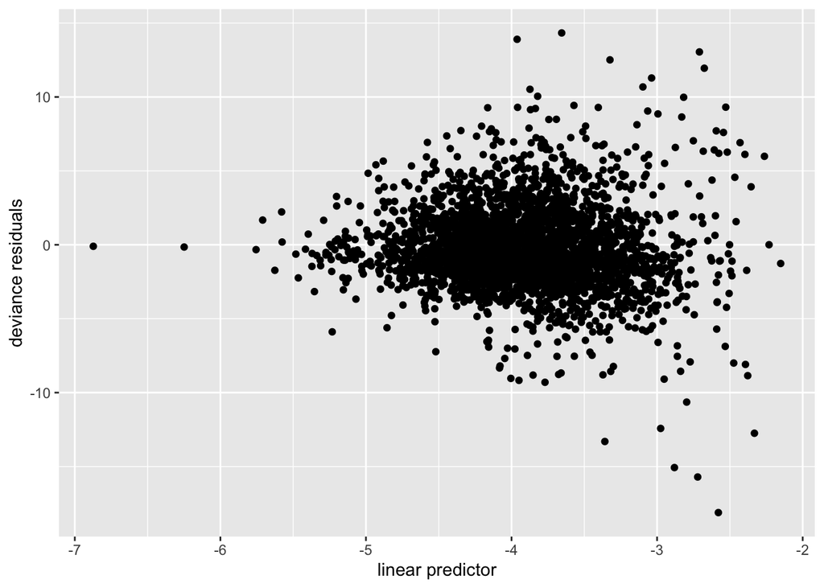

```r
dev_resi=county_data %>%
  mutate(devres=residuals(binaryreg), linpred=predict(binaryreg)) %>%
  ggplot()+
  geom_point(mapping=aes(x=linpred, y=devres))+
  labs(x="linear predictor", y="deviance residuals")
print(dev_resi)
```

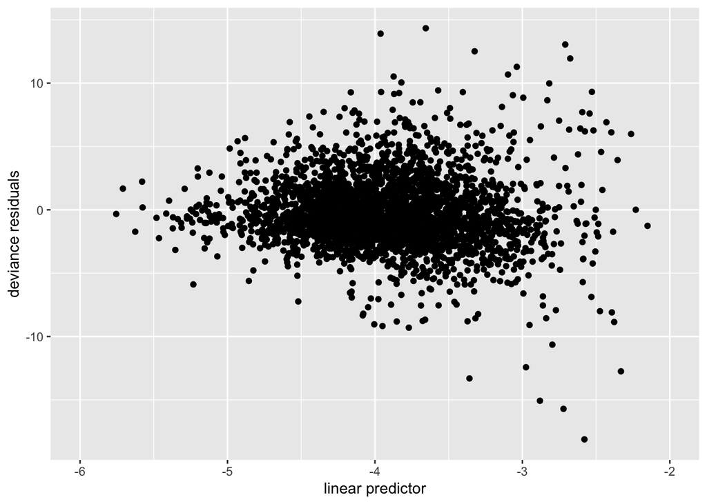

```r
dev_resi+xlim(-6,-2)
```

When we take the two potential outliers out, the plot looks better now.

## Q10

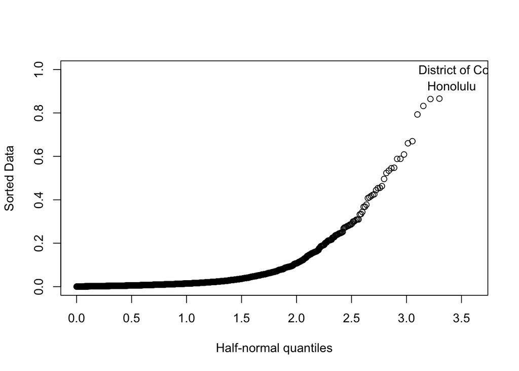

```r
halfnorm(hatvalues(binaryreg), labs=county_data$county)
```

District of Columbia and Honolulu look like outliers. We will investigate more.

```r
county_data %>%
slice(c(309, 537)) %>%
  print(width=Inf)
```

```
## # A tibble: 2 x 31
##   county               confirmed deaths state
##   <chr>                    <dbl>  <dbl> <fct>
## 1 District of Columbia     16370    641 District of Columbia
## 2 Honolulu                 12465    150 Hawaii
##   percent_fair_or_poor_health percent_smokers percent_adults_with_obesity
##                         <dbl>           <dbl>                       <dbl>
## 1                        13.0            16.0                        23.5
## 2                        13.0            11.0                        23.4
##   percent_with_access_to_exercise_opportunities percent_excessive_drinking
##                                           <dbl>                      <dbl>
## 1                                         100                         27.3
## 2                                          96.7                       20.4
##   percent_uninsured percent_some_college percent_unemployed
##               <dbl>                <dbl>              <dbl>
## 1              4.30                 81.2               5.55
## 2              4.13                 71.9               2.34
##   percent_children_in_poverty percent_single_parent_households
##                         <dbl>                            <dbl>
## 1                        24.5                             52.1
## 2                         9.8                             26.4
##   percent_severe_housing_problems overcrowding percent_adults_with_diabetes
##                             <dbl>        <dbl>                        <dbl>
## 1                            21.5         3.59                          8.1
## 2                            27.5         9.20                         10.4
##   percent_food_insecure percent_insufficient_sleep percent_uninsured_2
##                   <dbl>                      <dbl>               <dbl>
## 1                  11                         36.2                5.18
## 2                  10.5                       45.1                4.90
##   median_household_income average_traffic_volume_per_meter_of_major_roadways
##                     <dbl>                                              <dbl>
## 1                   82533                                               465.
## 2                   83695                                              1371.
##   percent_homeowners population_2 percent_less_than_18_years_of_age
##                <dbl>        <dbl>                             <dbl>
## 1               41.8       702455                              18.1
## 2               55.8       980080                              21.2
##   percent_65_and_over percent_black percent_asian percent_hispanic
##                 <dbl>         <dbl>         <dbl>            <dbl>
## 1                12.1         44.9           4.42             11.3
## 2                17.7          2.55         43.0              10.0
##   percent_female percent_rural
##            <dbl>         <dbl>
## 1           52.6         0
## 2           49.7         0.863
```

## Q11

```r
modAIC=step(binaryreg, trace = FALSE)
summary(modAIC)
```

```
##
## Call:
## glm(formula = cbind(deaths, confirmed - deaths) ~ state + percent_smokers +
##     percent_adults_with_obesity + percent_with_access_to_exercise_opportunities +
##     percent_excessive_drinking + percent_uninsured + percent_some_college +
##     percent_unemployed + percent_children_in_poverty + percent_single_parent_households +
##     percent_severe_housing_problems + overcrowding + percent_adults_with_diabetes +
##     percent_food_insecure + percent_insufficient_sleep + percent_uninsured_2 +
##     median_household_income + average_traffic_volume_per_meter_of_major_roadways +
##     percent_homeowners + population_2 + percent_less_than_18_years_of_age +
##     percent_65_and_over + percent_black + percent_asian + percent_hispanic +
##     percent_female + percent_rural, family = binomial, data = county_data)
##
## Deviance Residuals:
##      Min        1Q    Median        3Q       Max
## -18.1096   -1.7692   -0.5572    1.0661   14.2977
##
## Coefficients:
##                                                      Estimate Std. Error
## (Intercept)                                        -9.000e+00  1.926e-01
## stateAlaska                                        -2.540e-01  1.292e-01
## stateArizona                                        8.062e-01  4.273e-02
## stateArkansas                                       4.233e-01  3.549e-02
## stateCalifornia                                     1.495e-01  3.868e-02
## stateColorado                                       1.263e+00  3.582e-02
## stateConnecticut                                    1.823e+00  3.086e-02
## stateDelaware                                       6.176e-01  4.642e-02
## stateDistrict of Columbia                           6.419e-01  7.026e-02
## stateFlorida                                        5.484e-01  2.941e-02
## stateGeorgia                                        5.549e-01  2.520e-02
## stateHawaii                                        -7.682e-01  8.862e-02
## stateIdaho                                          1.428e-01  5.300e-02
## stateIllinois                                       7.416e-01  2.798e-02
## stateIndiana                                        9.656e-01  2.991e-02
## stateIowa                                           3.206e-01  4.096e-02
## stateKansas                                         3.677e-01  4.403e-02
## stateKentucky                                       2.304e-01  3.684e-02
## stateLouisiana                                      7.132e-01  2.820e-02
## stateMaine                                          9.086e-01  8.804e-02
## stateMaryland                                       6.637e-01  3.036e-02
```

[output cut: 129 more lines]

```
## percent_black                                        9.350  < 2e-16 ***
## percent_asian                                        9.996  < 2e-16 ***
## percent_hispanic                                    -5.388 7.14e-08 ***
## percent_female                                      21.815  < 2e-16 ***
## percent_rural                                       -4.502 6.74e-06 ***
## ---
## Signif. codes:  0 '***' 0.001 '**' 0.01 '*' 0.05 '.' 0.1 ' ' 1
##
## (Dispersion parameter for binomial family taken to be 1)
##
##     Null deviance: 109649  on 3092  degrees of freedom
## Residual deviance:  23001  on 3016  degrees of freedom
## AIC: 35343
##
## Number of Fisher Scoring iterations: 5
```

## Q12

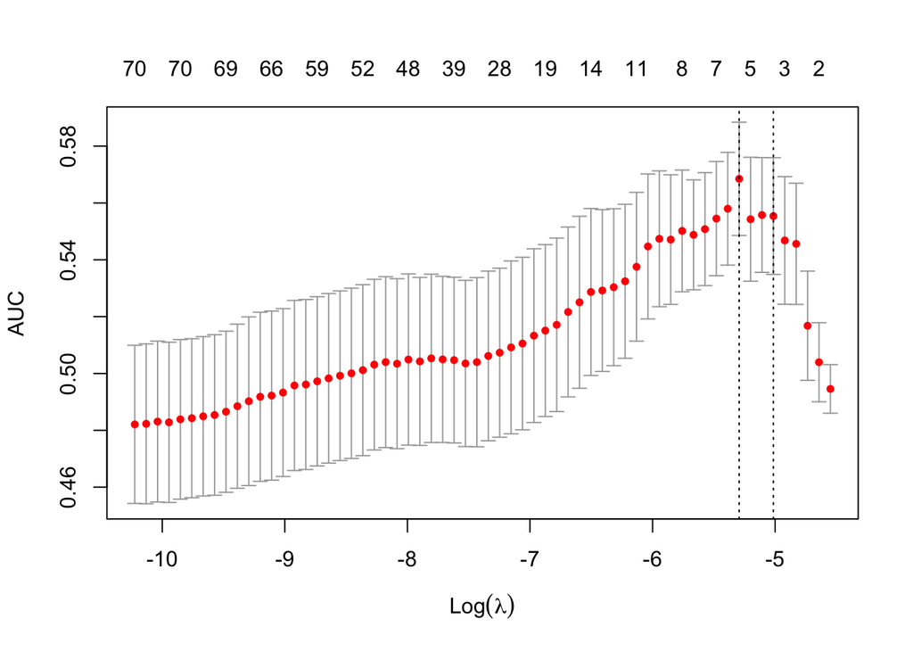

```r
x_vars=model.matrix(cbind(deaths, confirmed - deaths) ~ . - 1 - county,
                  data = county_data)
x_vars=x_vars[rep(1:nrow(county_data), each = 2), ]
y_vars=rep(c(1, 0), nrow(county_data))
combined=c(rbind(county_data$deaths, county_data$confirmed - county_data$deaths))
set.seed(6000)
cv_output=cv.glmnet(x_vars, y_vars, weights = combined, alpha = 1,
                      family = "binomial", type.measure = "auc")
plot(cv_output)
```

```r
cv_output$lambda.min
```

```
## [1] 0.005024779
```

```r
coef(cv_output, cv_output$lambda.min)
```

```
## 79 x 1 sparse Matrix of class "dgCMatrix"
##                                                                1
## (Intercept)                                        -3.931296e+00
## stateAlabama                                        .
## stateAlaska                                         .
## stateArizona                                        .
## stateArkansas                                       .
## stateCalifornia                                     .
## stateColorado                                       .
## stateConnecticut                                    .
## stateDelaware                                       .
## stateDistrict of Columbia                           .
## stateFlorida                                        .
## stateGeorgia                                        .
## stateHawaii                                         .
## stateIdaho                                          .
## stateIllinois                                       .
## stateIndiana                                        .
## stateIowa                                           .
## stateKansas                                         .
## stateKentucky                                       .
## stateLouisiana                                      .
## stateMaine                                          .
## stateMaryland                                       .
## stateMassachusetts                                  2.611336e-01
## stateMichigan                                       .
## stateMinnesota                                      .
## stateMississippi                                    .
## stateMissouri                                       .
## stateMontana                                        .
## stateNebraska                                       .
## stateNevada                                         .
## stateNew Hampshire                                  .
## stateNew Jersey                                     5.275124e-01
## stateNew Mexico                                     .
## stateNew York                                       4.419380e-01
## stateNorth Carolina                                 .
## stateNorth Dakota                                   .
## stateOhio                                           .
## stateOklahoma                                       .
```

[output cut: 26 more lines]

```
## percent_adults_with_diabetes                        .
## percent_food_insecure                               .
## percent_insufficient_sleep                          6.416121e-03
## percent_uninsured_2                                 .
## median_household_income                             .
## average_traffic_volume_per_meter_of_major_roadways  9.774846e-05
## percent_homeowners                                  .
## population_2                                        .
## percent_less_than_18_years_of_age                   .
## percent_65_and_over                                 .
## percent_black                                       .
## percent_asian                                       .
## percent_hispanic                                    .
## percent_female                                      .
## percent_rural                                       .
```